# Visualizing the Anthropogenic Causes of Climate Change

Aditya Jadhav

April 18, 2018

# 1. Introduction

### The Team:

- **Aditya Jadhav aaj2146**
- **Yang Qiao yq2223**
- **Simran Lamba sl4228**

As millennials who grew up in the developing world, we are first hand witnesses to the drastic effects of environmental degradation and wanton urbanization. We firmly believe that data science will be a key force that helps mitigate the impending challenges that climate change will present, not only through technological innovations but also through greater awareness and influence on public policy. An exploratory data analysis of the climate change movement raises some interesting socio-political questions.

In our literature survey, we came across Capitalism Vs The Climate (Naomi Klein) [https://thischangeseverything.org/book/], a book that discusses the issue of climate change in a socio political context through the late 80s to the present time. The author makes statements pertaining to the causes of climate change from a purely political standpoint. One of the key claims is that free market capitalism has directly led to a phenomenal rise in global CO<sub>2</sub> emissions. The book outlines how trade deals make provisions that inhibit and stifle measures taken by various countries to adopt green technology. Another by product of these trade deals is the availability of inexpensive goods manufactured in places where environmental regulations are lax. The past three decades have seen an precedented rise in consumerism as evidenced by indicators like household credit card debt.

We wish to verify these claims by analyzing the data in the references she provides as well as through other publicly available data. We shall get in to the details of this data in the next section. In particular, we wish to answer the following questions with Capitalsim vs The Climate as the broader theme:

### Questions:

1. Landmark “Free-Trade” agreements seem to coincide with landmark climate negotiations. How effective are these agreements? Do these free trade negotiations actually inhibit the policies that climate agreements want to put in place?
2. How does the health of an economy affect public perception of climate change?
3. How consumerism and a unhealthy demand for cheaper material goods has contributed to global warming?
4. How climate science which is often discredited by vested interests has been perceived by the general public over the years. Is there any correlation with the aforementioned free trade deals and lesser agreeability with scientific fact?

# 2. Description of Data

1. **Global Temperature**  
   https://climate.nasa.gov/vital-signs/global-temperature/  
   This time series plot shows the change in global surface temperature relative to 1951-1980 average temperatures. Seventeen of the 18 warmest years in the 136-year record all have occurred since 2001, with the exception of 1998. The year 2016 ranks as the warmest on record. (Source: NASA/GISS). This research is broadly consistent with similar constructions prepared by the Climatic Research Unit and the National Oceanic and Atmospheric Administration.
2. **Atmospheric CO2 content** http://scrippsco2.ucsd.edu/assets/data/atmospheric/stations/in_situ_co2/monthly/monthly_in_situ_co2_mlo.csv  
   We took data from the Scripps Institute’s CO2 program at UC San Diego. The data we chose to work with is the monthly record of atmospheric CO2 content.
3. **Household Credit Card Debt** https://wallethub.com/edu/credit-card-debt/25533/#revolving-consumer-debt  
   We chose to look at the yearly credit card debt per household in the United States as an estimate of consumerism. This data is sourced from the Federal Reserve by WalletHub. It is a part of WalletHub’s annual report. The data is adjusted for year on year inflation.
4. **Public perception and sentiment towards climate change.**  
   http://www.aei.org/publication/aei-public-opinion-study-polls-on-the-environment-energy-global-warming-and-nuclear-power-2/  
   In the book the author claims that over the past three decades there has been a systematic attack on the scientific consensus about global warming in the United States. We have gathered data that tracks the year on year public sentiment about global warming in terms of how much people trust the science surrounding it. We can verify the claim made by the author in this regard.

# 3. Analysis of Data Quality

##### 1. Public opinion data.

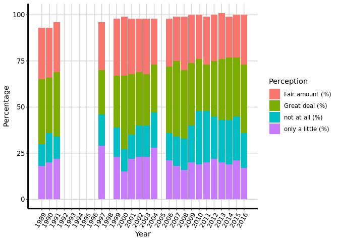

```r
library(dplyr)
library(ggplot2)
library(tidyverse)
library(readxl)
library(plyr)
data <- read_excel("global warming and climate change.xlsx")
new_data <- gather(data, "Perception", "Percentage", 2:5)
 graph <- ggplot() + geom_bar(aes(y = Percentage, x = Year, fill = Perception), data = new_data, stat="identity")+scale_x_continuous(breaks=seq(1989,2016,1))+
   theme(axis.line = element_line(size=1, colour = "black"),
        panel.grid.major = element_line(colour = "#d3d3d3"), panel.grid.minor = element_blank(),
        panel.border = element_blank(), panel.background = element_blank()) +
  theme(plot.title = element_text(size = 14, family = "Tahoma", face = "bold"),
        text=element_text(family="Tahoma"),
        axis.text.x=element_text(colour="black", size = 10, angle = 60, hjust =1),
        axis.text.y=element_text(colour="black", size = 10))
 graph
```

##### 2. Credit Card Debt per Household

Here we chose to look at the credit card debt per household as an estimate of a rising consumerist lifestyle promoted by free market capitalism. We hyposthesize that the surplus of mass produced goods in the free market economy gives impetus to increased wanton consumption. This increased consumption of inexpensive material goods is correlated with a sharp rise in CO<sub>2</sub> emissions. We hope to explore this relationship with this data.

An interesting observation we make is the spike in debt at the peak of the economic recession in 2008.

```r
library(dplyr)
library(ggplot2)
library(tidyverse)
library(readxl)

credit <- read_excel("credit card debt by household.xlsx")
g <- ggplot(credit, aes(Year_Q4,Per_Household_Debt))+geom_line(color = "green")+
      ggtitle("Household Credit Card Debt")+
    theme_grey(16)+xlab("Year")+ylab("Credit card debt in USD")
  theme(legend.title = element_blank())
```

```
## List of 1
##  $ legend.title: list()
##   ..- attr(*, "class")= chr [1:2] "element_blank" "element"
##  - attr(*, "class")= chr [1:2] "theme" "gg"
##  - attr(*, "complete")= logi FALSE
##  - attr(*, "validate")= logi TRUE
```

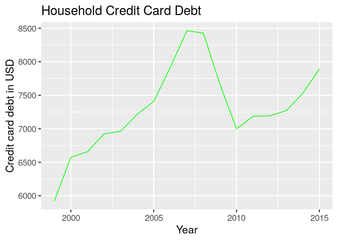

```r
g
```

##### 3. Atmospheric CO<sub>2</sub> content

For this data we look at the measured concentration of CO<sub>2</sub> in the earth’s atmosphere for the years 1988 through 2015

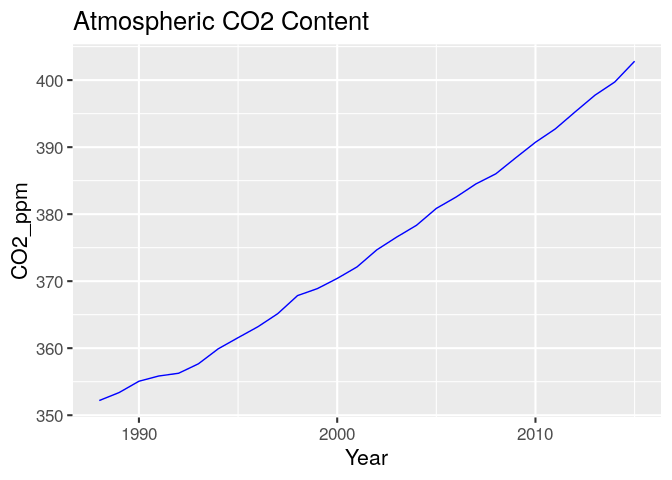

```r
library(dplyr)
library(ggplot2)
library(tidyverse)
library(readxl)

credit <- read_excel("Emissions.xlsx")
g <- ggplot(credit, aes(Year,CO2_ppm))+geom_line(color="blue")+
      ggtitle("Atmospheric CO2 Content")+
    theme_grey(16)+
  theme(legend.title = element_blank())
g
```

##### 4. Temperature Data

For the temperature plots we have taken the GLOBAL LAND-OCEAN TEMPERATURE INDEX compiled by NASA’s Goddard Institute for Space Studies. It illustrates the change in global temperature relative to a certain baseline (average for the years 1951-1980).

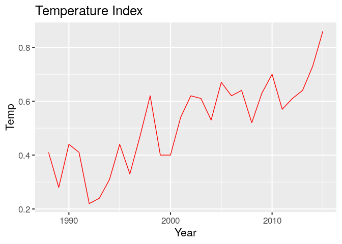

```r
library(dplyr)
library(ggplot2)
library(tidyverse)
library(readxl)

credit <- read_excel("Temperature.xlsx")
g <- ggplot(credit, aes(Year,Temp))+geom_line(color="red")+
      ggtitle("Temperature Index")+
    theme_grey(16)+
  theme(legend.title = element_blank())
g
```

# 4. Main Analysis (Exploratory Data Analysis)

A major chunk of the project was dedicated to gathering the right kind of data to answer the questions we wish to answer. To this end we ran literature survey of the references provide by Klein in her book that supposedly support her claims.

Firstly, we would like to present a timeline beginning on 1988 that virtually marks an epoch:

An interactive timeline for this information is given below.

```r
library(timevis)

data <- data.frame(
  id      = 1:13,
  content = c("IPCC formed, first session", "Goddard Institute presents in Congress",
              "Fall of the Communist Bloc", "First IPCC negotiations", "UN Climate Convention in Rio", "WTO is formed", "Kyoto protocol", "Housing Crisis", "Warmest year on record", "WTO deems China's subsidy of solar panels illegal", "TPP is ratified", "Green Economy Act, Canada", "Paris Agreement"),
  start   = c("1989", "1988",
              "1989", "1989","1992","1994","1997","2008","2011","2012","2013","2014","2015"),
  end     = c(NA, NA, NA, NA,NA, NA, NA, NA,NA, NA, NA, NA,NA)
)

timevis(data)
```

[interactive chart not shown]

We want to investigate the following claim(s) made in the book with data:

The rise of free market capitalism at the end of the Cold War led to the proliferation of free market capitalism throughout the world. The author claims that the free market ideology which presupposes infinite growth at the cost of rising consumption is fundamentally at loggerheads with actions that combat climate change. She supports this claim by pointing out that since 1988 when the first climate negotiations began, the CO<sub>2</sub> emissions have actually grown at an unprecedented rate.

Additionally, the author claims that by outsourcing the manufacturing to the developing world (India, China, Brazil etc.) where environmental laws are lax or sometimes nonexistent has led to cheaper mass produced goods. These goods are manufactured with at a massive cost to the environment. Moreover, transporting these goods across long distances in diesel shipment trawlers contributes massively to global CO<sub>2</sub> emissions. Also, the availability of such inexpensive goods on a massive scale has lead to a highly consumerist lifestyle.

To verify these claims we chose to look at household credit card debt to estimate the rising consumerism, the global surface temperature index and atmospheric CO<sub>2</sub> content. On the public policy front, certain vested interests that profit from fossil fuels have been actively discrediting climate science. To gauge this we decided to look at public perception of climate change.

Our methodology was as follows:

- We take the greenhouse effect caused by CO<sub>2</sub> as a baseline starting point. Therefore, atmospheric CO<sub>2</sub> content becomes the prime variable we test our hypothesis against. This means that if we find enough evidence that suggests a particular parameter causes rise in CO<sub>2</sub> emissions we will accept the corresponding claim as verified.
- To this end, we first check correlations between CO<sub>2</sub> emissions and the different socio-economic parameters that we are looking at. Look at their distributions
- Check the effect of each parameter individually against CO<sub>2</sub> emissions

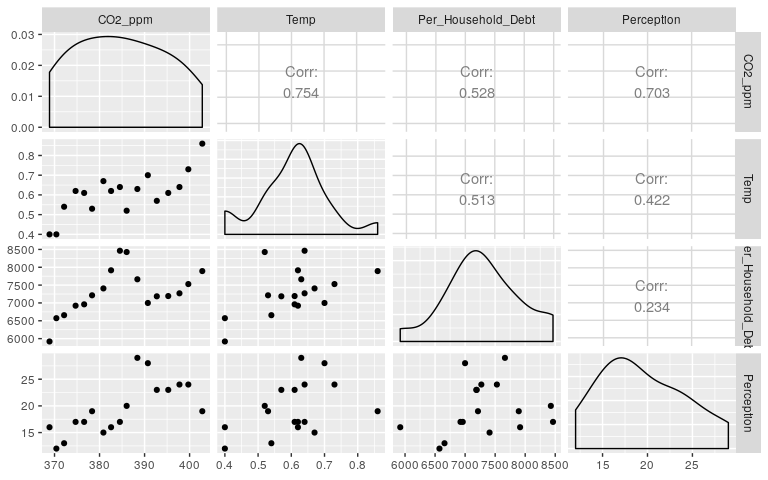

```r
library(dplyr)
library(ggplot2)
library(tidyverse)
library(readxl)
library(GGally)

data <- read_excel("raw_data.xlsx")
data<-data[c(12:28),c(2:5)]
ggpairs(data)
```

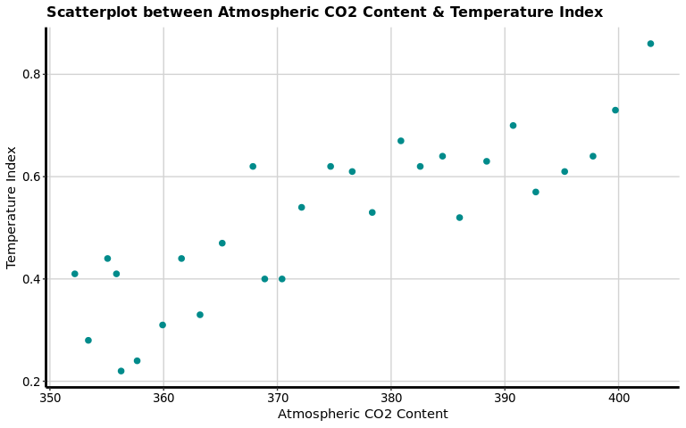

```r
library(dplyr)
library(ggplot2)
library(tidyverse)
library(readxl)
data <- read_excel("raw_data.xlsx")
new_data <- data[c(12:28),]

ggplot(data, aes(x=CO2_ppm, y=Temp)) + geom_point(color = "cyan4", size = 2)+
ggtitle("Scatterplot between Atmospheric CO2 Content & Temperature Index")+
      xlab("Atmospheric CO2 Content")+ylab("Temperature Index")+
  theme(axis.line = element_line(size=1, colour = "black"),
        panel.grid.major = element_line(colour = "#d3d3d3"), panel.grid.minor = element_blank(),
        panel.border = element_blank(), panel.background = element_blank()) +
  theme(plot.title = element_text(size = 12, family = "Tahoma", face = "bold"),
        text=element_text(family="Tahoma"),
        axis.text.x=element_text(colour="black", size = 10),
        axis.text.y=element_text(colour="black", size = 10))
```

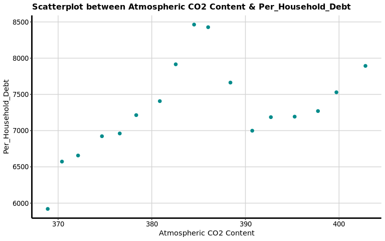

```r
ggplot(new_data, aes(x=CO2_ppm, y=Per_Household_Debt)) + geom_point(color = "cyan4", size = 2)+
ggtitle("Scatterplot between Atmospheric CO2 Content & Per_Household_Debt")+
      xlab("Atmospheric CO2 Content")+ylab("Per_Household_Debt")+
  theme(axis.line = element_line(size=1, colour = "black"),
        panel.grid.major = element_line(colour = "#d3d3d3"), panel.grid.minor = element_blank(),
        panel.border = element_blank(), panel.background = element_blank()) +
  theme(plot.title = element_text(size = 12, family = "Tahoma", face = "bold"),
        text=element_text(family="Tahoma"),
        axis.text.x=element_text(colour="black", size = 10),
        axis.text.y=element_text(colour="black", size = 10))
```

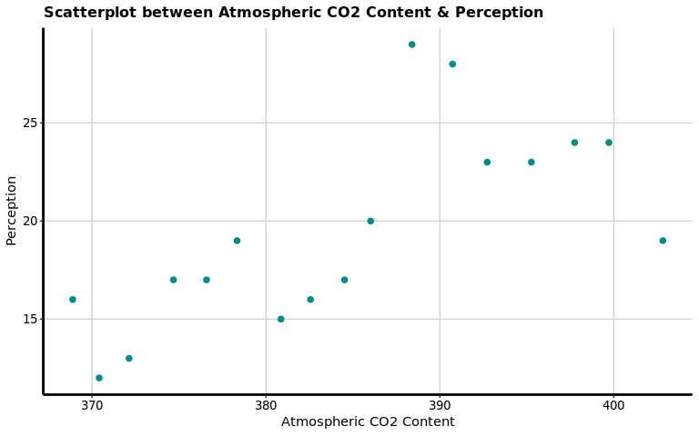

```r
ggplot(new_data, aes(x=CO2_ppm, y=Perception)) + geom_point(color = "cyan4", size = 2)+
ggtitle("Scatterplot between Atmospheric CO2 Content & Perception")+
      xlab("Atmospheric CO2 Content")+ylab("Perception")+
  theme(axis.line = element_line(size=1, colour = "black"),
        panel.grid.major = element_line(colour = "#d3d3d3"), panel.grid.minor = element_blank(),
        panel.border = element_blank(), panel.background = element_blank()) +
  theme(plot.title = element_text(size = 12, family = "Tahoma", face = "bold"),
        text=element_text(family="Tahoma"),
        axis.text.x=element_text(colour="black", size = 10),
        axis.text.y=element_text(colour="black", size = 10))
```

###### Inferences

From the scatter plots we see that the strong correlation between atmospheric CO<sub>2</sub> and temperature index as we had expected from our baseline assumption about the greenhouse effect.

Counterintuitively, public opinion on the threat that climate change poses seems to have diminished against the backdrop of rising global temperatures. A larger percentage of people now believe that climate change is not such a serious threat.

Finally we plot the collective effect of these three parameters on CO<sub>2</sub> levels in a consolidated graph:

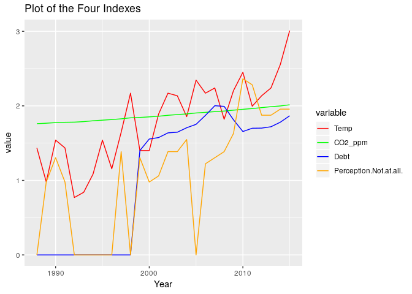

```r
library(ggplot2)
# 1988-2015 data
#credit card debt 99-15
data2 = read.csv("Debt.csv", header =  T)
# perception 89-15
data3 = read.csv("Perception.csv", header = T)
# global temperature change  88-15
data5 = read.csv("Temperature.csv", header = T)
# CO2 Emission change
data1 = read.csv("Emissions.csv", header = T)

data = read.csv("Climate.csv", header = T)

for (i in 1:28){
  data$Temp[i] = data$Temp[i] * 700 /200
}

for (i in 1:28){
  data$CO2_ppm[i]=data$CO2_ppm[i]/200
}

for (i in 11:28){
  data$Debt[i]=data$Debt[i]/21.14/200
}

for (i in 2:28){
  data$Perception.Not.at.all.[i]=data$Perception.Not.at.all.[i]*16.3/200
}
write.csv(data, file = "climate_scaled.csv")

library(reshape2)
dd = melt(data, id=c("Year"))
ggplot(dd) + geom_line(aes(x=Year, y=value, colour=variable)) +
  scale_colour_manual(values=c("red","green","blue", "orange")) +ggtitle("Plot of the Four Indexes")
```

# 5. Executive Summary

To summarize we first look at the raw data we have selected. Namely, public opinion on global warming, CO<sub>2</sub> in the atmosphere, credit card debt per household and global surface temperature index. The plots presented earlier are tidied up.

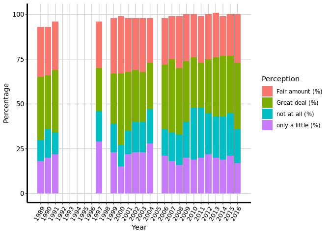

```r
library(dplyr)
library(ggplot2)
library(tidyverse)
library(readxl)
library(plyr)
data <- read_excel("global warming and climate change.xlsx")
new_data <- gather(data, "Perception", "Percentage", 2:5)
 graph <- ggplot() + geom_bar(aes(y = Percentage, x = Year, fill = Perception), data = new_data, stat="identity")+scale_x_continuous(breaks=seq(1989,2016,1))+
   theme(axis.line = element_line(size=1, colour = "black"),
        panel.grid.major = element_line(colour = "#d3d3d3"), panel.grid.minor = element_blank(),
        panel.border = element_blank(), panel.background = element_blank()) +
  theme(plot.title = element_text(size = 14, family = "Tahoma", face = "bold"),
        text=element_text(family="Tahoma"),
        axis.text.x=element_text(colour="black", size = 10, angle = 60, hjust =1),
        axis.text.y=element_text(colour="black", size = 10))
 graph
```

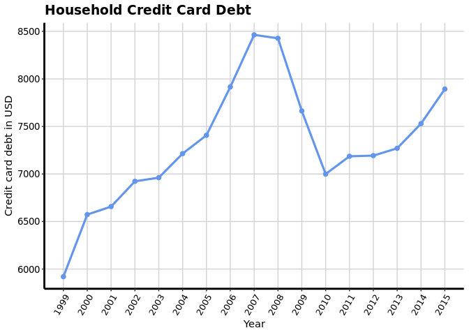

```r
library(dplyr)
library(ggplot2)
library(tidyverse)
library(readxl)

credit <- read_excel("credit card debt by household.xlsx")

g <- ggplot(credit, aes(Year_Q4,Per_Household_Debt))+geom_line(color = "cornflowerblue",lwd=1.1)+
      geom_point(color = "cornflowerblue", size = 2)+
      scale_x_continuous(breaks=seq(1999,2015,1))+
      ggtitle("Household Credit Card Debt")+
      xlab("Year")+ylab("Credit card debt in USD")+
  theme(axis.line = element_line(size=1, colour = "black"),
        panel.grid.major = element_line(colour = "#d3d3d3"), panel.grid.minor = element_blank(),
        panel.border = element_blank(), panel.background = element_blank()) +
  theme(plot.title = element_text(size = 14, family = "Tahoma", face = "bold"),
        text=element_text(family="Tahoma"),
        axis.text.x=element_text(colour="black", size = 10, angle = 60, hjust =1),
        axis.text.y=element_text(colour="black", size = 10))

g
```

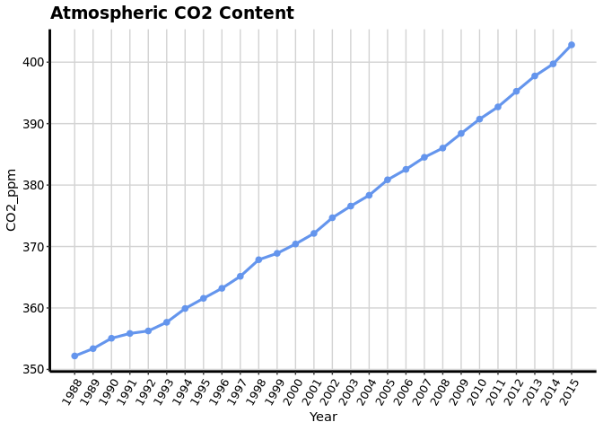

```r
library(dplyr)
library(ggplot2)
library(tidyverse)
library(readxl)

emi <- read_excel("Emissions.xlsx")

g <- ggplot(emi, aes(Year,CO2_ppm))+geom_line(color = "cornflowerblue",lwd=1.1)+
      geom_point(color = "cornflowerblue", size = 2)+
      scale_x_continuous(breaks=seq(1988,2015,1))+
      ggtitle("Atmospheric CO2 Content")+
      xlab("Year")+ylab("CO2_ppm")+
  theme(axis.line = element_line(size=1, colour = "black"),
        panel.grid.major = element_line(colour = "#d3d3d3"), panel.grid.minor = element_blank(),
        panel.border = element_blank(), panel.background = element_blank()) +
  theme(plot.title = element_text(size = 14, family = "Tahoma", face = "bold"),
        text=element_text(family="Tahoma"),
        axis.text.x=element_text(colour="black", size = 10, angle = 60, hjust =1),
        axis.text.y=element_text(colour="black", size = 10))
g
```

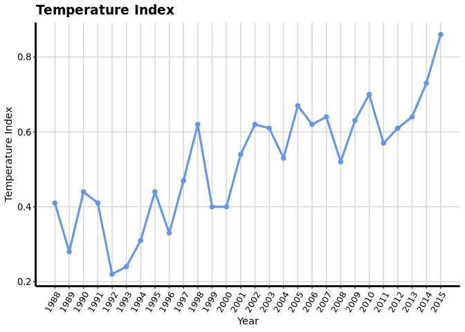

```r
library(dplyr)
library(ggplot2)
library(tidyverse)
library(readxl)

temp <- read_excel("Temperature.xlsx")

g <- ggplot(temp, aes(Year,Temp))+geom_line(color = "cornflowerblue",lwd=1.1)+
      geom_point(color = "cornflowerblue", size = 2)+
      scale_x_continuous(breaks=seq(1988,2015,1))+
      ggtitle("Temperature Index")+
      xlab("Year")+ylab("Temperature Index")+
  theme(axis.line = element_line(size=1, colour = "black"),
        panel.grid.major = element_line(colour = "#d3d3d3"), panel.grid.minor = element_blank(),
        panel.border = element_blank(), panel.background = element_blank()) +
  theme(plot.title = element_text(size = 14, family = "Tahoma", face = "bold"),
        text=element_text(family="Tahoma"),
        axis.text.x=element_text(colour="black", size = 10, angle = 60, hjust =1),
        axis.text.y=element_text(colour="black", size = 10))
g
```

###### (From the main analysis section)

We want to investigate the following claim(s) made in the book with data:

The rise of free market capitalism at the end of the Cold War led to the proliferation of free market capitalism throughout the world. The author claims that the free market ideology which presupposes infinite growth at the cost of rising consumption is fundamentally at loggerheads with actions that combat climate change. She supports this claim by pointing out that since 1988 when the first climate negotiations began, the CO<sub>2</sub> emissions have actually grown at an unprecedented rate.

Additionally, the author claims that by outsourcing the manufacturing to the developing world (India, China, Brazil etc.) where environmental laws are lax or sometimes nonexistent has led to cheaper mass produced goods. These goods are manufactured with at a massive cost to the environment. Moreover, transporting these goods across long distances in diesel shipment trawlers contributes massively to global CO<sub>2</sub> emissions. Also, the availability of such inexpensive goods on a massive scale has lead to a highly consumerist lifestyle.

To verify these claims we chose to look at household credit card debt to estimate the rising consumerism, the global surface temperature index and atmospheric CO<sub>2</sub> content. On the public policy front, certain vested interests that profit from fossil fuels have been actively discrediting climate science. To gauge this we decided to look at public perception of climate change.

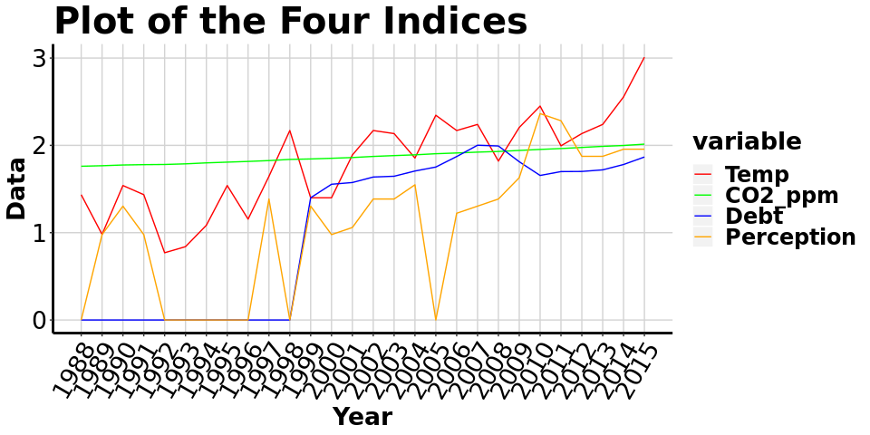

```r
library(ggplot2)
# 1988-2015 data
#credit card debt 99-15
data2 = read.csv("Debt.csv", header =  T)
# perception 89-15
data3 = read.csv("Perception.csv", header = T)
# global temperature change  88-15
data5 = read.csv("Temperature.csv", header = T)
# CO2 Emission change
data1 = read.csv("Emissions.csv", header = T)

data = read.csv("Climate.csv", header = T)

for (i in 1:28){
  data$Temp[i] = data$Temp[i] * 700 /200
}

for (i in 1:28){
  data$CO2_ppm[i]=data$CO2_ppm[i]/200
}

for (i in 11:28){
  data$Debt[i]=data$Debt[i]/21.14/200
}

for (i in 2:28){
  data$Perception[i]=data$Perception.Not.at.all.[i]*16.3/200
}
data = data[,c(1:4, 6)]
write.csv(data, file = "climate_scaled.csv")

library(reshape2)
dd = melt(data, id=c("Year"))

ggplot(dd) + geom_line(aes(x=Year, y=value, colour=variable)) +
  scale_colour_manual(values=c("red","green","blue", "orange")) +ggtitle("Plot of the Four Indices")+
  xlab("Year")+ylab("Data")+
      scale_x_continuous(breaks=seq(1988,2015,1))+
  theme(axis.line = element_line(size=1, colour = "black"),
        panel.grid.major = element_line(colour = "#d3d3d3"), panel.grid.minor = element_blank(),
        panel.border = element_blank(), panel.background = element_blank()) +
  theme(plot.title = element_text(size = 30, family = "Tahoma", face = "bold"),
        text=element_text(family="Tahoma"),
        axis.text.x=element_text(colour="black", size = 20, angle = 60, hjust =1),
        axis.text.y=element_text(colour="black", size = 20),
        axis.title.x=element_text(size=20,face="bold"),
        axis.title.y=element_text(size=20,face="bold"),
        legend.text=element_text(size=18,face="bold"),
        legend.title=element_text(size=20,face="bold"))
```

# 6. Interactive Part(s)

- This is an interactive version of the consolidated time series plot. It is inspired from the Bloomberg plot where all the parameters are superimposed on the dependent variable which is the temperature index. The events we wish to highlight are annotated on the graph:

https://plot.ly/~sl4228/30/interactive-part/

- This graph can be annotated with landmark events that occurred in that 30 year window. This is achieved with this interactive timeline.

[interactive chart not shown]

# 7. Conclusion

Through this project we took up a problem that we are passionate about, scanned relevant references to gather data to answer the questions we had and in the process got a taste of real life exploratory data analysis. In the future, we would like further explore the niches of this problem like public perception. In conclusion, we hope more EDAV is done in the area of climate science. The reproducibility of this project means it could be a starting point in that direction.